# Text Data and Word Frequencies

Adam Gilbert

November 08, 2023

```python
import pandas as pd
from plotnine import *

zillow = pd.read_csv("https://raw.githubusercontent.com/agmath/agmath.github.io/master/data/classification/austin_zillow_data.csv")
```

The data we’ll be working with is a data set from Zillow, containing several properties sold in the Austin, TX region. There are 7498 properties and 16 variables recorded on each property. We can see the first three rows of the data set below.

| id | city | description | homeType | latitude | longitude | garageSpaces | hasSpa | yearBuilt | numOfPatioAndPorchFeatures | lotSizeSqFt | avgSchoolRating | MedianStudentsPerTeacher | numOfBathrooms | numOfBedrooms | priceRange |
| --- | --- | --- | --- | --- | --- | --- | --- | --- | --- | --- | --- | --- | --- | --- | --- |
| 1 | austin | 7300 Annette Cv, Austin, TX 78724 is a single family home that contains 1,419 sq ft and was built in 2007. It contains 2 bedrooms and 3 bathrooms. | Single Family | 30.28529 | -97.64630 | 1 | FALSE | 2007 | 0 | 6795 | 3.666667 | 11 | 3 | 2 | 250000-350000 |
| 2 | austin | Extravagant and luxurious 5 bedroom, 4.5 bath property in the beautiful Tarrytown neighborhood. The high-ceilinged main level is window-lined throughout with a clear view of the impressive fenced-in b… | Single Family | 30.29841 | -97.77605 | 2 | TRUE | 2015 | 0 | 8276 | 7.000000 | 16 | 5 | 5 | 650000+ |
| 3 | austin | HIGH RENTABLE AREA! Beautifully kept duplex located minutes away from great restaurants, shopping, and easy access to I-35 and HWY 183! Each unit features 3 bed 2 bath with an amazing floor plan! | Multiple Occupancy | 30.32740 | -97.69390 | 1 | FALSE | 1967 | 0 | 8886 | 3.333333 | 15 | 4 | 6 | 0-250000 |

In this notebook we’ll be focused on attempting to see whether the most frequently used words in the `description` column vary across the different property `priceRange` categories. Before moving forward, we’ll subset the data frame to contain only those columns we are working with in this notebook.

```python
zillow = zillow[["description", "priceRange"]]
```

| description | priceRange |
| --- | --- |
| 7300 Annette Cv, Austin, TX 78724 is a single family home that contains 1,419 sq ft and was built in 2007. It contains 2 bedrooms and 3 bathrooms. | 250000-350000 |
| Extravagant and luxurious 5 bedroom, 4.5 bath property in the beautiful Tarrytown neighborhood. The high-ceilinged main level is window-lined throughout with a clear view of the impressive fenced-in b… | 650000+ |
| HIGH RENTABLE AREA! Beautifully kept duplex located minutes away from great restaurants, shopping, and easy access to I-35 and HWY 183! Each unit features 3 bed 2 bath with an amazing floor plan! | 0-250000 |

Now we’ll move to processing that `description` column into individual tokens (words), filtering out “low-information” tokens (called *stopwords*), then we’ll compute word frequencies, and finally we’ll produce a plot of the most frequent words in each `priceRange` category.

### Preprocessing the `description` Column

There are a few things we’ll want to do before breaking our descriptions into individual words. First, we’ll convert all letters to lowercase, so that *neighborhood* and *Neighborhood* are not counted as two distinct tokens.

```python
zillow.loc[:, "description"] = zillow["description"].str.lower()
```

We can see the updated descriptions below.

| description | priceRange |
| --- | --- |
| 7300 annette cv, austin, tx 78724 is a single family home that contains 1,419 sq ft and was built in 2007. it contains 2 bedrooms and 3 bathrooms. | 250000-350000 |
| extravagant and luxurious 5 bedroom, 4.5 bath property in the beautiful tarrytown neighborhood. the high-ceilinged main level is window-lined throughout with a clear view of the impressive fenced-in b… | 650000+ |
| high rentable area! beautifully kept duplex located minutes away from great restaurants, shopping, and easy access to i-35 and hwy 183! each unit features 3 bed 2 bath with an amazing floor plan! | 0-250000 |

Notice that all of the characters in the description column are now lowercase! You may want to also remove punctuation marks and digits from the description column. You can do this with `.str_replace()` and a regular expression, but I’ll leave that to you! Now let’s tokenize our descriptions.

### Tokenizing the `description` Column

We’ll need to split the `description` column across each whitespace character found in our descriptions. From there, we’ll need to add the `priceRange` category into our data frame of word tokens. Then we’ll use `.melt()` to transform our data frame from wide to long format. You can un-comment each `tokens_df` line in the code cell below to see the state of the data you are working with after each step.

```python
tokens_df = zillow["description"].str.split(" ", expand = True)
#tokens_df
tokens_df["priceRange"] = zillow["priceRange"]
#tokens_df
tokenized_descriptions = tokens_df.melt(id_vars = ["priceRange"], value_name = "word").drop("variable", axis = 1).reset_index(drop = True)
```

We can see the first ten rows of `tokenized_descriptions` below.

| priceRange | word |
| --- | --- |
| 250000-350000 | 7300 |
| 650000+ | extravagant |
| 0-250000 | high |
| 250000-350000 | great |
| 650000+ | for |
| 0-250000 | under |
| 450000-650000 | beautiful |
| 0-250000 | 11612 |
| 350000-450000 | 161 |
| 650000+ | stunning |

We can count the most frequently occurring words using `.value_counts()`.

```python
tokenized_descriptions.value_counts("word", sort = True)
```

```
## word
## and           21252
## the           13470
## a             11837
## in            10883
## with          10084
##               ...
## distances         1
## distanced         1
## distance),        1
## distance"         1
## …                 1
## Name: count, Length: 32179, dtype: int64
```

Perhaps not surprising, the most frequent words are “low-information” words. They don’t really tell us about the properties – these words/tokens are commonly referred to as *stopwords*. I’ll read in a dictionary of common stopwords and then we can use what we know about Python merges (specifically anti-joins) in order to filter out the stopwords.

### Removing Stopwords

As mentioned, stopwords are commonly occurring tokens that are unlikely to provide useful information for our analyses. There are several lists of stopwords available – I found one that I like [here](https://raw.githubusercontent.com/juliasilge/tidytext/main/data-raw/stop_words.csv). We could even add to this list if we wanted (and we probably do, since we know that all of these descriptions have to do with *homes*). I’ll leave that to you as well though.

Let’s read in the data frame of stopwords.

```python
stopwords = pd.read_csv("https://raw.githubusercontent.com/juliasilge/tidytext/main/data-raw/stop_words.csv")
```

We can see the first few stopwords below, ignoring the `lexicon` column.

| word | lexicon |
| --- | --- |
| a | SMART |
| a’s | SMART |
| able | SMART |
| about | SMART |
| above | SMART |
| according | SMART |
| accordingly | SMART |
| across | SMART |
| actually | SMART |
| after | SMART |

Now let’s use an anti-join to remove those words!

```python
temp_list_outer = tokenized_descriptions.merge(stopwords, how = "outer", indicator = True, left_on = "word", right_on = "word")

tokenized_no_stopwords = temp_list_outer[(temp_list_outer._merge == "left_only")].drop(["_merge"], axis = 1).reset_index()
```

Now we can recompute the counts.

```python
tokenized_no_stopwords.value_counts("word", sort = True)
```

```
## word
## home        7529
##             7344
## &           6044
## kitchen     3244
## \r\r\n      3094
##             ...
## dcs            1
## dble           1
## dbl.           1
## dazzled!       1
## …              1
## Name: count, Length: 31642, dtype: int64
```

That looks better! There are still some issues here with spaces, symbols, and special characters. We can remove those with regular expressions. I’ll leave most of this to you, but below I’ll do a bit of naive filtering to remove any tokens containing fewer than 5 characters and also any NULL tokens.

```python
tokenized_no_stopwords = tokenized_no_stopwords[tokenized_no_stopwords["word"].notnull()]
tokenized_no_stopwords = tokenized_no_stopwords[tokenized_no_stopwords["word"].apply(lambda x: len(x) > 4)]

tokenized_no_stopwords.value_counts("word", sort = True)
```

```
## word
## kitchen                   3244
## master                    2922
## family                    2724
## bedrooms                  2647
## living                    2498
##                           ...
## each,\r\r\n5th               1
## e-mail.\r\r\n\r\r\nph;       1
## e-mail                       1
## décor.                       1
## “updated,                    1
## Name: count, Length: 26954, dtype: int64
```

That looks a little better.

### A Plot of Most Frequent Words in Descriptions

Let’s finish this off by producing a barplot of the most commonly occurring words in each `priceRange` category.

```
## <Figure Size: (640 x 480)>
```

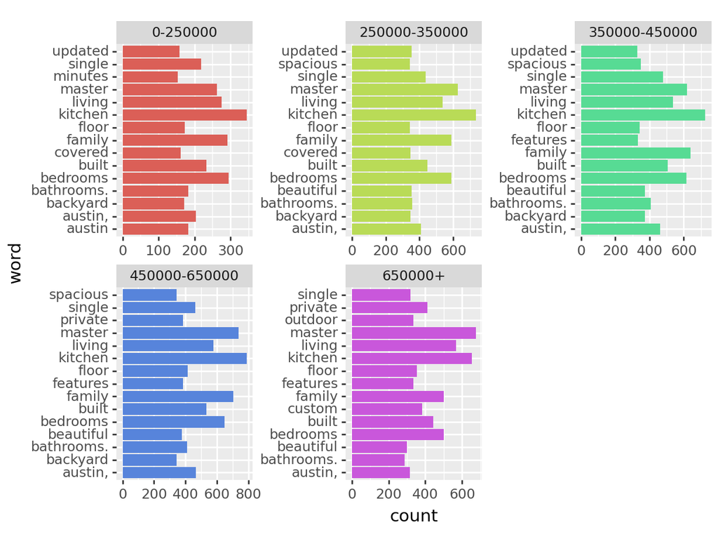

```python
tokenized_description_counts = tokenized_no_stopwords.groupby(["priceRange", "word"]).size().reset_index()
tokenized_description_counts.columns = ["priceRange", "word", "count"]
tokenized_description_counts = tokenized_description_counts.sort_values("count", ascending = False)

(
  ggplot(data = tokenized_description_counts[tokenized_description_counts.groupby('priceRange')['count'].rank(ascending=False) <= 15]) +
  geom_col(aes(x = "word", y = "count", fill = "priceRange"), show_legend = False) +
  coord_flip() +
  facet_wrap("~priceRange", scales = "free")
)
```

There it is! Can you see any differences in words used across the descriptions of the different categories? We could do even better if we added *read-estate*-specific tokens to our data frame of stopwords. I hope you find this helpful.